# Composite method simulation

Lisa DeBruine

28/01/2020

Parameters

```r
stim_n <- 50 # number of stimuli in the full image set
r <- 0 # correlation between the visual and proxy trait values
comp_n <- 10 # number of images in the high and low composites
rater_n <- 100 # number of raters doing the rating
error_sd <- 0.5 # how good the raters are at detecting the visual difference. 0 would be perfect perception
```

Simulate a set of `stim_n` stimuli with “visual” and “proxy” trait values, with no correlation between the two. For example, for the trait of psychopathy, the proxy value could be a score on a psychopathy questionnaire, while the visual score is how “psychopathic” the stimulus looks (on average).

```r
dat <- rnorm_multi(
  n = stim_n,
  vars = 2,
  r = r,
  varnames = c("visual", "proxy")
)
```

Choose the top and bottom `comp_n` stimuli, based on proxy trait values. Caluclate the mean proxy and visual values for the two groups.

```r
composites <- dat %>%
  mutate(grp = case_when(
    min_rank(proxy) <= comp_n ~ "low",
    min_rank(proxy) > nrow(.)-comp_n ~ "high"
  )) %>%
  filter(!is.na(grp)) %>%
  group_by(grp) %>%
  summarise(mean_proxy = mean(proxy),
            mean_visual = mean(visual))
```

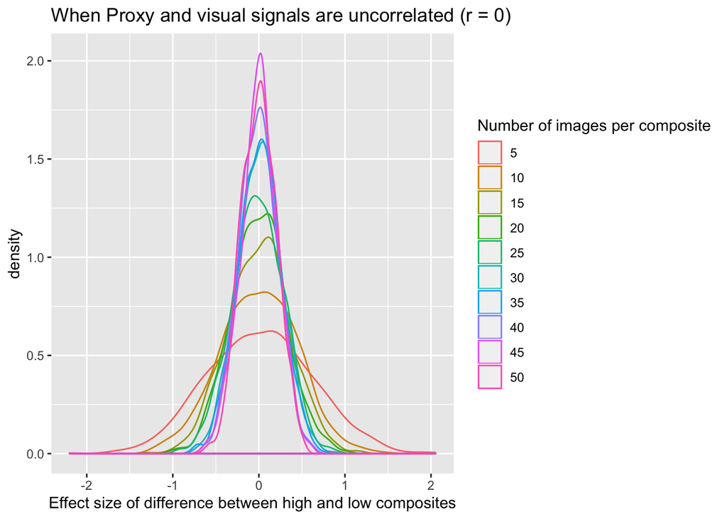

```r
n <- seq(5, 50, 5)
xxx <- map(n, function(x) {
  map_dbl(rep(x, 1000), function(x) {mean(rnorm(x)) - mean(rnorm(x))})
  })

dx <- as.data.frame(xxx)
names(dx) <- n
gather(dx, n, score, `5`:`50`) %>%
  mutate(n = as.integer(n)) %>%
  #group_by(n) %>%
  #summarise(score = mean(score > .2)) %>%
  ggplot(aes(score, color = as.factor(n))) +
  geom_density() +
  xlab("Effect size of difference between high and low composites")  +
  scale_color_discrete(name = "Number of images per composite") +
  ggtitle("When Proxy and visual signals are uncorrelated (r = 0)")
```

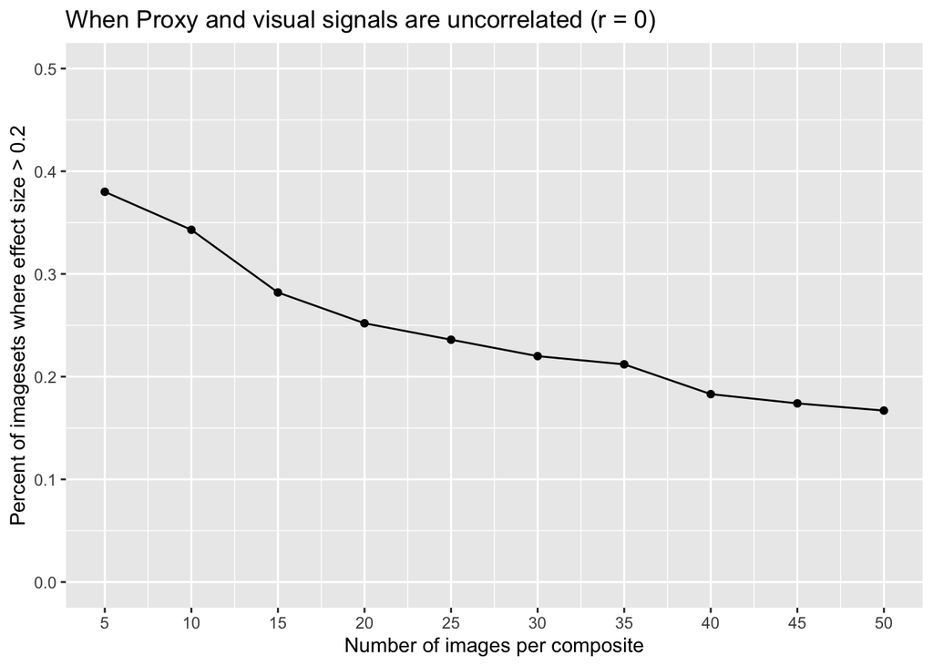

```r
gather(dx, n, score, `5`:`50`) %>%
  mutate(n = as.integer(n)) %>%
  group_by(n) %>%
  summarise(score = mean(score > .2)) %>%
  ggplot(aes(n, score)) +
  geom_point( ) +
  geom_line() +
  xlab("Number of images per composite")  +
  ylab("Percent of imagesets where effect size > 0.2") +
  ggtitle("When Proxy and visual signals are uncorrelated (r = 0)") +
  scale_x_continuous(breaks = n) +
  ylim(0, 0.5)
```

Simulate `rater_n` raters. They will perceive the visual values of the composites with some error and choose the one that is higher.

```r
h <- composites$mean_visual[1] + rnorm(rater_n, 0, error_sd)
l <- composites$mean_visual[2] + rnorm(rater_n, 0, error_sd)

binom.test(sum(h > l), rater_n, p = 0.5, "greater" )
```

```
##
##  Exact binomial test
##
## data:  sum(h > l) and rater_n
## number of successes = 37, number of trials = 100, p-value = 0.9967
## alternative hypothesis: true probability of success is greater than 0.5
## 95 percent confidence interval:
##  0.2893554 1.0000000
## sample estimates:
## probability of success
##                   0.37
```

Wrap this in a function to simulate a single image set, repeated over `reps` sets of raters. Return the proportion of rating studies where a binomail test of the results was positive. (Set `alternative` to “greater” for a directional test.)

```r
sim <- function(stim_n = 30,
                r = 0.9,
                comp_n = 10,
                rater_n = 150,
                error_sd = 0.2,
                reps = 100,
                alternative = "greater",
                alpha = 0.05) {

  dat <- rnorm_multi(
    n = stim_n,
    vars = 2,
    r = r,
    varnames = c("visual", "proxy")
  )

  composites <- dat %>%
    mutate(grp = case_when(
      min_rank(proxy) <= comp_n ~ "low",
      min_rank(proxy) > nrow(.)-comp_n ~ "high"
    )) %>%
    filter(!is.na(grp)) %>%
    group_by(grp) %>%
    summarise(mean_proxy = mean(proxy),
              mean_visual = mean(visual))

  sim_p <- map_dbl(1:reps, function(x) {
    h <- composites$mean_visual[1] + rnorm(rater_n, 0, error_sd)
    l <- composites$mean_visual[2] + rnorm(rater_n, 0, error_sd)

    bt <- binom.test(sum(h > l), rater_n,
                     p = 0.5, alternative)

    bt$p.value
  })

  mean(sim_p < alpha)
}
```

Running the function once gives you the proportion of “replication studies” where this single simulated image set will give you a significant result in the predicted direction.

```r
sim(stim_n, r, comp_n, rater_n, error_sd, 100, "greater")
```

```
## [1] 0
```

The simulation above is just for a single random image set. We can also run this simulation 100 times, to simulate 100 different random image sets.

```r
x <- replicate(100, sim(stim_n, r, comp_n, rater_n, error_sd, 100))
```

The plot below shows the distribution of the probability that a study of a random imageset will give you a significant result in the predicted direction.

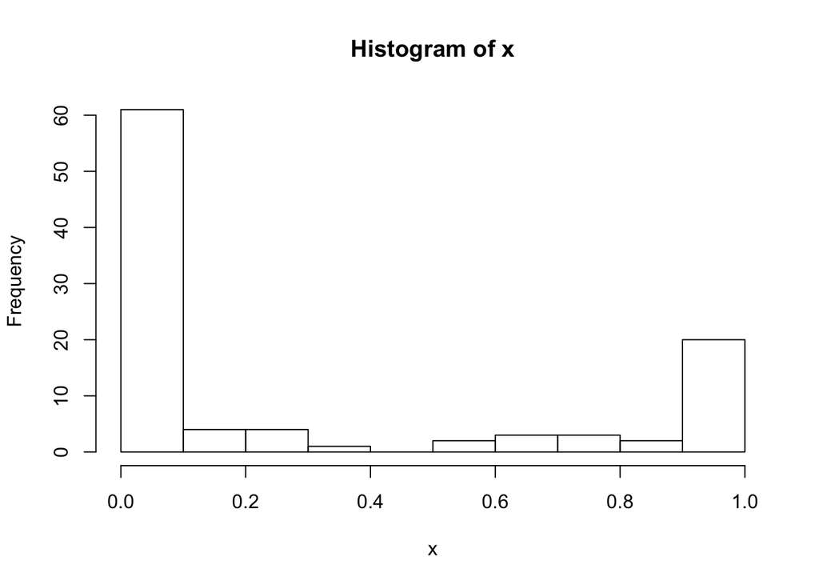

```r
pcnt <- round(mean(x == 1)*100)
hist(x)
```

You can see that 15% of values are 1. If r = 0, then this represents the probability that a random image set, where the proxy value has *no* relation to the visual value, will always give you significant results in the predicted direction.

You can also run a non-directional version.

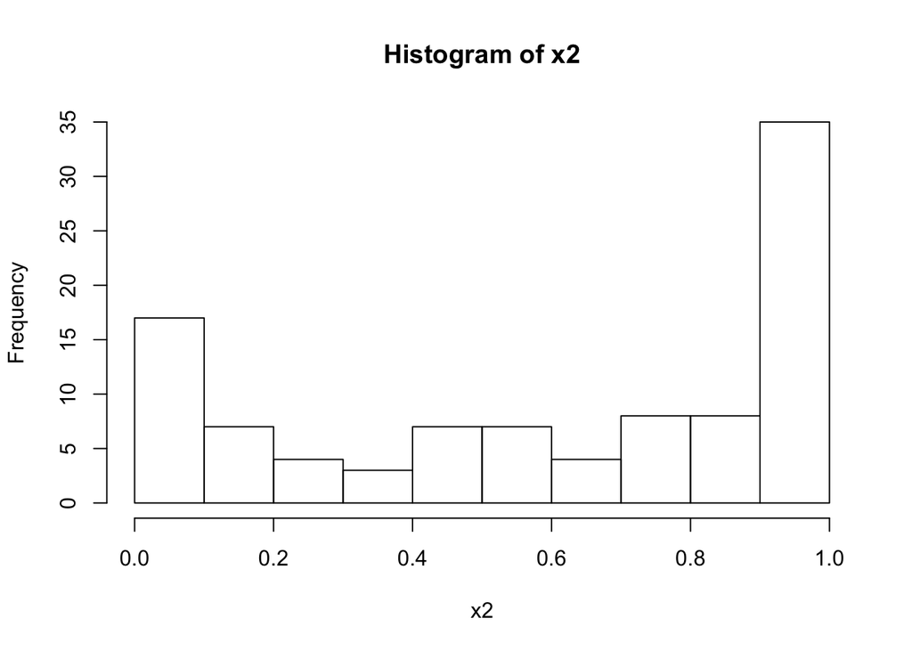

```r
x2 <- replicate(100, sim(stim_n, r, comp_n, rater_n, error_sd, 100, "two.sided"))
hist(x2)
```

If you decrease the number of images in the composites, increase the number of raters, or decrease the error_sd (increasing the accuracy/agreement of rater perceptions of the visual value), this false positive rate will increase towards 50% (or 100% if the hypothesis is not directional).

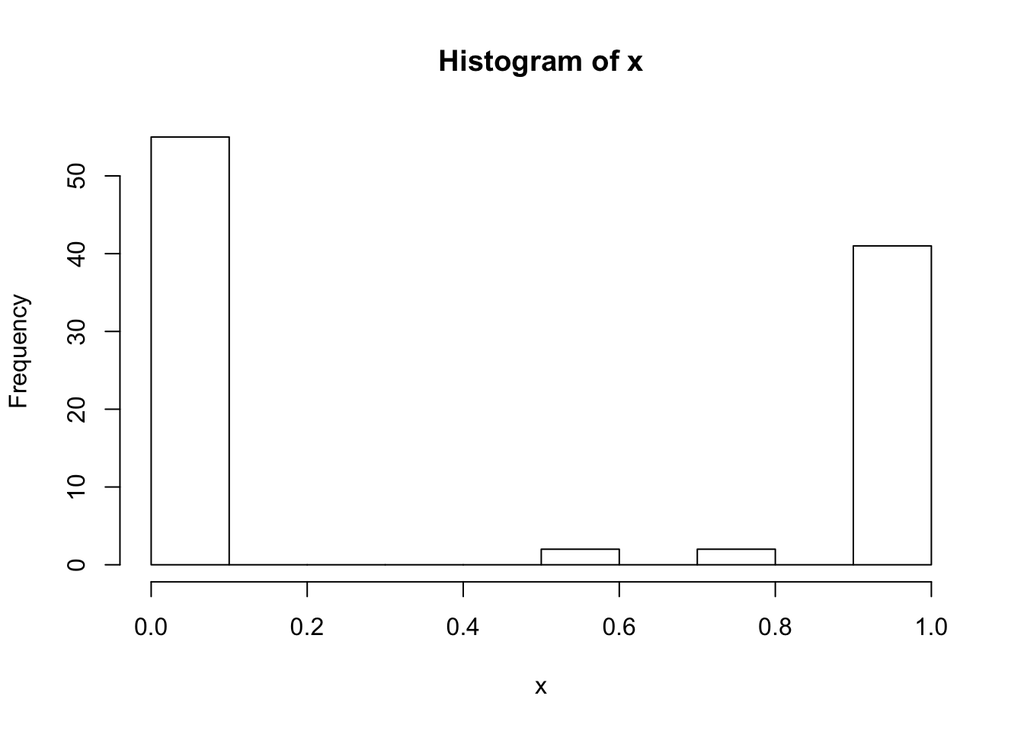

```r
stim_n <- 30
r <- 0
comp_n <- 6
rater_n <- 300
error_sd <- 0.2
x <- replicate(100, sim(stim_n, r, comp_n, rater_n, error_sd, 100))
hist(x)
```